# Customizing an MCMC

NIMBLE training materials module

NIMBLE Development Team

# The pump model

Here’s the graph of the pump model.

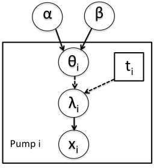

Here we set up the pump model.

```r
pumpCode <- nimbleCode({
  for (i in 1:N){

      # likelihood (data model)
      x[i] ~ dpois(lambda[i])

      # latent process (random effects)
      # linear predictor
      lambda[i] <- theta[i]*t[i]
      # random effects distribution
      theta[i] ~ dgamma(alpha,beta)
  }
  # priors on hyperparameters
  alpha ~ dexp(1.0)
  beta ~ dgamma(0.1,1.0)
})
```

```r
N <- 10
t <- c(94.3, 15.7, 62.9, 126, 5.24, 31.4, 1.05, 1.05, 2.1, 10.5)
x <- c(5, 1, 5, 14, 3, 19, 1, 1, 4, 22)
pumpConsts <- list(t = t, N = 10)
pumpData <- list(x = x)
pumpInits <- list(alpha = 1, beta = 1,
         theta = rep(0.1, pumpConsts$N))
pump <- nimbleModel(pumpCode,
          data = pumpData, constants = pumpConsts, inits = pumpInits)
```

```
## defining model...
```

```
## building model...
```

```
## setting data and initial values...
```

```
## checking model...   (use nimbleModel(..., check = FALSE) to skip model check)
```

```
## model building finished
```

```r
Cpump <- compileNimble(pump)
```

# NIMBLE’s default MCMC

Here are the results from running NIMBLE’s default MCMC:

```r
pumpConf <- configureMCMC(pump, print = TRUE)
```

```
## [1]  RW sampler: alpha
## [2]  conjugate_dgamma_dgamma sampler: beta,  dep_dgamma: theta[1], theta[2], theta[3], theta[4], theta[5], theta[6], theta[7], theta[8], theta[9], theta[10]
## [3]  conjugate_dgamma_dpois sampler: theta[1],  dep_dpois: x[1]
## [4]  conjugate_dgamma_dpois sampler: theta[2],  dep_dpois: x[2]
## [5]  conjugate_dgamma_dpois sampler: theta[3],  dep_dpois: x[3]
## [6]  conjugate_dgamma_dpois sampler: theta[4],  dep_dpois: x[4]
## [7]  conjugate_dgamma_dpois sampler: theta[5],  dep_dpois: x[5]
## [8]  conjugate_dgamma_dpois sampler: theta[6],  dep_dpois: x[6]
## [9]  conjugate_dgamma_dpois sampler: theta[7],  dep_dpois: x[7]
## [10] conjugate_dgamma_dpois sampler: theta[8],  dep_dpois: x[8]
## [11] conjugate_dgamma_dpois sampler: theta[9],  dep_dpois: x[9]
## [12] conjugate_dgamma_dpois sampler: theta[10],  dep_dpois: x[10]
```

```r
pumpConf$addMonitors(c('alpha', 'beta', 'theta'))
```

```
## thin = 1: alpha, beta, theta
```

```r
pumpMCMC <- buildMCMC(pumpConf)
CpumpMCMC <- compileNimble(pumpMCMC, project = pump)

niter <- 1000
burnin <- 200

CpumpMCMC$run(niter)
```

```r
samples <- as.matrix(CpumpMCMC$mvSamples)

library(coda)
mcmc <- as.mcmc(samples[(burnin+1):nrow(samples), ])
crosscorr(mcmc[ , c('alpha', 'beta', 'theta[1]', 'theta[2]', 'theta[3]')])
```

```
##               alpha       beta    theta[1]   theta[2]    theta[3]
## alpha    1.00000000 0.60416784  0.10057783 0.15267456  0.09535809
## beta     0.60416784 1.00000000  0.04810690 0.06997961  0.07937788
## theta[1] 0.10057783 0.04810690  1.00000000 0.02798919 -0.04201807
## theta[2] 0.15267456 0.06997961  0.02798919 1.00000000  0.01370887
## theta[3] 0.09535809 0.07937788 -0.04201807 0.01370887  1.00000000
```

```r
effectiveSize(mcmc)
```

```
##     alpha      beta  theta[1]  theta[2]  theta[3]  theta[4]  theta[5]
##  96.76119 179.24613 800.00000 800.00000 800.00000 736.91802 733.47827
##  theta[6]  theta[7]  theta[8]  theta[9] theta[10]
## 800.00000 800.00000 800.00000 618.76819 668.04858
```

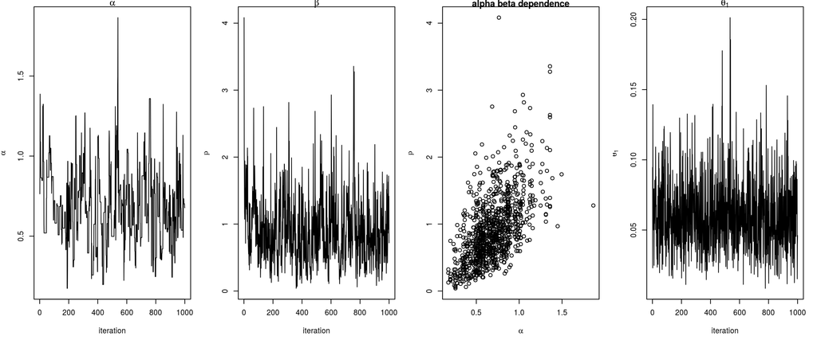

```r
par(mfrow = c(1, 4), mai = c(.6, .5, .1, .2))
tsplot(samples[ , 'alpha'], xlab = 'iteration',
     ylab = expression(alpha), main = expression(alpha))
tsplot(samples[ , 'beta'], xlab = 'iteration',
     ylab = expression(beta), main = expression(beta))
plot(samples[ , 'alpha'], samples[ , 'beta'], xlab = expression(alpha),
     ylab = expression(beta), main = paste(expression(alpha), expression(beta), "dependence"))
tsplot(samples[ , 'theta[1]'], xlab = 'iteration',
     ylab = expression(theta[1]), main = expression(theta[1]))
```

# Customizing samplers

As those who’ve worked with MCMC before know, MCMC is a family of algorithms and there are many ways to run an MCMC for any given model, including the choice of the kind of sampler used for each parameter in the model.

One of NIMBLE’s most important features is that users can easily modify the MCMC algorithm used for their model. The easiest thing to do is to start with NIMBLE’s default MCMC and then make modifications.

```r
pumpConf <- configureMCMC(pump)
pumpConf$addMonitors(c('alpha', 'beta', 'theta'))
```

```
## thin = 1: alpha, beta, theta
```

```r
pumpConf$getSamplers()
```

```
## [[1]]
## RW sampler: alpha
## [[2]]
## conjugate_dgamma_dgamma sampler: beta,  dep_dgamma: theta[1], theta[2], theta[3], theta[4], theta[5], theta[6], theta[7], theta[8], theta[9], theta[10]
## [[3]]
## conjugate_dgamma_dpois sampler: theta[1],  dep_dpois: x[1]
## [[4]]
## conjugate_dgamma_dpois sampler: theta[2],  dep_dpois: x[2]
## [[5]]
## conjugate_dgamma_dpois sampler: theta[3],  dep_dpois: x[3]
## [[6]]
## conjugate_dgamma_dpois sampler: theta[4],  dep_dpois: x[4]
## [[7]]
## conjugate_dgamma_dpois sampler: theta[5],  dep_dpois: x[5]
## [[8]]
## conjugate_dgamma_dpois sampler: theta[6],  dep_dpois: x[6]
## [[9]]
## conjugate_dgamma_dpois sampler: theta[7],  dep_dpois: x[7]
## [[10]]
## conjugate_dgamma_dpois sampler: theta[8],  dep_dpois: x[8]
## [[11]]
## conjugate_dgamma_dpois sampler: theta[9],  dep_dpois: x[9]
## [[12]]
## conjugate_dgamma_dpois sampler: theta[10],  dep_dpois: x[10]
```

```r
pumpConf$removeSamplers('alpha')
pumpConf$addSampler(target = c('alpha'), type = 'slice')

pumpMCMC <- buildMCMC(pumpConf)
CpumpMCMC <- compileNimble(pumpMCMC, project = pump, resetFunctions = TRUE)

Cpump$setInits(pumpInits)
set.seed(0)
CpumpMCMC$run(niter)
```

We can look at diagnostics and see if the change in samplers had an effect. Interestingly, despite the posterior correlation between `alpha` and `beta`, a simple change just to the univariate sampler for `alpha` has had a real effect on MCMC performance.

Caveat: the real question is the effective sample size per unit of computation time, but we don’t assess that here.

```r
samples2 <- as.matrix(CpumpMCMC$mvSamples)

mcmc2 <- as.mcmc(samples2[(burnin+1):nrow(samples2), ])
crosscorr(mcmc2[ , c('alpha', 'beta', 'theta[1]', 'theta[2]', 'theta[3]')])
```

```
##               alpha       beta     theta[1]     theta[2]    theta[3]
## alpha    1.00000000 0.67433842  0.079863684  0.185706641  0.10491676
## beta     0.67433842 1.00000000  0.040722187  0.083438828  0.04500886
## theta[1] 0.07986368 0.04072219  1.000000000 -0.006635474  0.02622484
## theta[2] 0.18570664 0.08343883 -0.006635474  1.000000000 -0.01027202
## theta[3] 0.10491676 0.04500886  0.026224841 -0.010272015  1.00000000
```

```r
effectiveSize(mcmc2)
```

```
##     alpha      beta  theta[1]  theta[2]  theta[3]  theta[4]  theta[5]
##  201.3994  169.8293  800.0000  800.0000  800.0000 1136.0644  694.3200
##  theta[6]  theta[7]  theta[8]  theta[9] theta[10]
##  713.9069  800.0000  800.0000  661.2942  800.0000
```

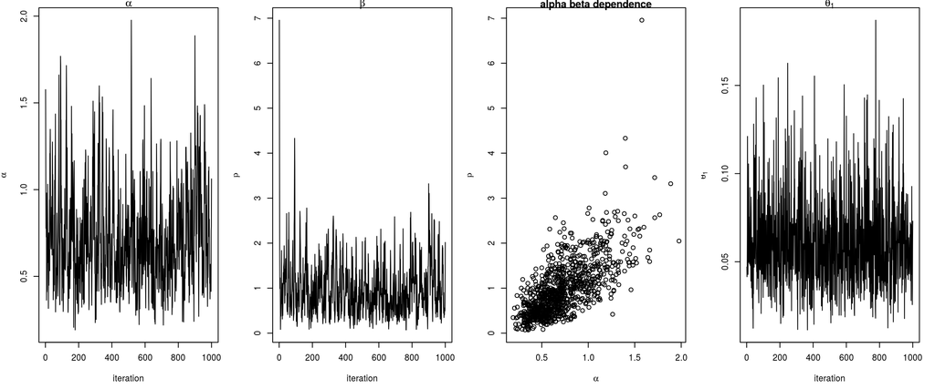

```r
par(mfrow = c(1, 4), mai = c(.6, .5, .1, .2))
plot(samples2[ , 'alpha'], type = 'l', xlab = 'iteration',
     ylab = expression(alpha), main = expression(alpha))
plot(samples2[ , 'beta'], type = 'l', xlab = 'iteration',
     ylab = expression(beta), main = expression(beta))
plot(samples2[ , 'alpha'], samples2[ , 'beta'], xlab = expression(alpha),
     ylab = expression(beta), main = paste(expression(alpha), expression(beta), "dependence"))
plot(samples2[ , 'theta[1]'], type = 'l', xlab = 'iteration',
     ylab = expression(theta[1]), main = expression(theta[1]))
```

# Blocking parameters

Often a key factor that reduces MCMC performance is dependence between parameters that limits the ability of univariate samplers to move very far. A standard strategy is to sample correlated parameters in blocks. Unlike many other MCMC engines, NIMBLE makes it easy for users to choose what parameters to sample in blocks.

We’ll try that here for `alpha` and `beta`.

```r
pumpConf$getSamplers()
```

```
## [[1]]
## conjugate_dgamma_dgamma sampler: beta,  dep_dgamma: theta[1], theta[2], theta[3], theta[4], theta[5], theta[6], theta[7], theta[8], theta[9], theta[10]
## [[2]]
## conjugate_dgamma_dpois sampler: theta[1],  dep_dpois: x[1]
## [[3]]
## conjugate_dgamma_dpois sampler: theta[2],  dep_dpois: x[2]
## [[4]]
## conjugate_dgamma_dpois sampler: theta[3],  dep_dpois: x[3]
## [[5]]
## conjugate_dgamma_dpois sampler: theta[4],  dep_dpois: x[4]
## [[6]]
## conjugate_dgamma_dpois sampler: theta[5],  dep_dpois: x[5]
## [[7]]
## conjugate_dgamma_dpois sampler: theta[6],  dep_dpois: x[6]
## [[8]]
## conjugate_dgamma_dpois sampler: theta[7],  dep_dpois: x[7]
## [[9]]
## conjugate_dgamma_dpois sampler: theta[8],  dep_dpois: x[8]
## [[10]]
## conjugate_dgamma_dpois sampler: theta[9],  dep_dpois: x[9]
## [[11]]
## conjugate_dgamma_dpois sampler: theta[10],  dep_dpois: x[10]
## [[12]]
## slice sampler: alpha
```

```r
pumpConf$removeSamplers(c('alpha', 'beta'))
pumpConf$addSampler(target = c('alpha','beta'), type = 'RW_block',
control = list(adaptInterval = 100))

pumpMCMC <- buildMCMC(pumpConf)
CpumpMCMC <- compileNimble(pumpMCMC, project = pump, resetFunctions = TRUE)

Cpump$setInits(pumpInits)
set.seed(0)
CpumpMCMC$run(niter)
```

```r
samples3 <- as.matrix(CpumpMCMC$mvSamples)
mcmc3 <- as.mcmc(samples3[(burnin+1):nrow(samples3), ])
crosscorr(mcmc3[ , c('alpha', 'beta', 'theta[1]', 'theta[2]', 'theta[3]')])
```

```
##               alpha       beta     theta[1]     theta[2]    theta[3]
## alpha    1.00000000 0.81300310  0.143241344  0.235995961  0.06863297
## beta     0.81300310 1.00000000  0.103948344  0.185363485  0.04732009
## theta[1] 0.14324134 0.10394834  1.000000000 -0.008541716  0.01183020
## theta[2] 0.23599596 0.18536349 -0.008541716  1.000000000 -0.02629862
## theta[3] 0.06863297 0.04732009  0.011830196 -0.026298621  1.00000000
```

```r
effectiveSize(mcmc3)
```

```
##     alpha      beta  theta[1]  theta[2]  theta[3]  theta[4]  theta[5]
##  29.96019  28.00181 800.00000 695.49198 800.00000 800.00000 462.96972
##  theta[6]  theta[7]  theta[8]  theta[9] theta[10]
## 800.00000 658.45161 598.51866 800.00000 800.00000
```

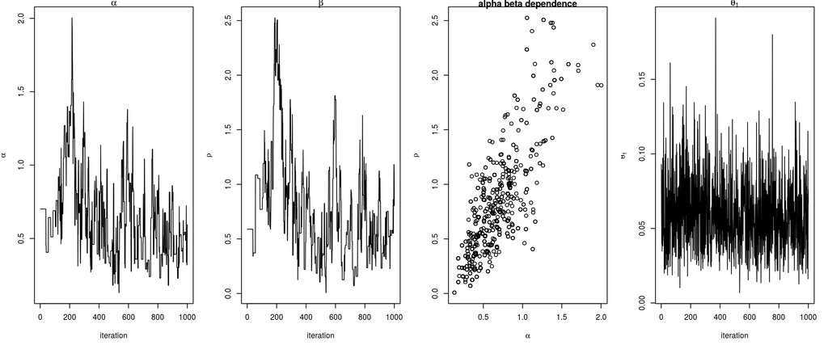

```r
par(mfrow = c(1, 4), mai = c(.6, .5, .1, .2))
plot(samples3[ , 'alpha'], type = 'l', xlab = 'iteration',
     ylab = expression(alpha), main = expression(alpha))
plot(samples3[ , 'beta'], type = 'l', xlab = 'iteration',
     ylab = expression(beta), main = expression(beta))
plot(samples3[ , 'alpha'], samples3[ , 'beta'], xlab = expression(alpha),
     ylab = expression(beta), main = paste(expression(alpha), expression(beta), "dependence"))
plot(samples3[ , 'theta[1]'], type = 'l', xlab = 'iteration',
     ylab = expression(theta[1]), main = expression(theta[1]))
```

In this case the block sampler appears to be less effective, but it might just be that the adaptation hasn’t had enough time to take full effect in only 1000 iterations. Very often block sampling gives big improvements.